# HW2 p8105 James Dalgleish jld2227

James Dalgleish

September 27, 2018

#### Problem 1

Instructions(I’m choosing to include these to make it a bit easier to grade): “Read and clean the data; retain line, station, name, station latitude / longitude, routes served, entry, vending, entrance type, and ADA compliance. Convert the entry variable from character (YES vs NO) to a logical variable (the ifelse or recode function may be useful).”

```r
subway_data = read_csv("./problem1/NYC_Transit_Subway_Entrance_And_Exit_Data.csv") %>%
  janitor::clean_names() %>%
  select(c("line","station_name","station_latitude","station_longitude",
           starts_with("route"),"entry","vending","ada")) %>%
  mutate(entry = recode(entry,"YES" = TRUE, "NO" = FALSE))
subway_data
```

```
## # A tibble: 1,868 x 18
##    line  station_name station_latitude station_longitu~ route1 route2
##    <chr> <chr>                   <dbl>            <dbl> <chr>  <chr>
##  1 4 Av~ 25th St                  40.7            -74.0 R      <NA>
##  2 4 Av~ 25th St                  40.7            -74.0 R      <NA>
##  3 4 Av~ 36th St                  40.7            -74.0 N      R
##  4 4 Av~ 36th St                  40.7            -74.0 N      R
##  5 4 Av~ 36th St                  40.7            -74.0 N      R
##  6 4 Av~ 45th St                  40.6            -74.0 R      <NA>
##  7 4 Av~ 45th St                  40.6            -74.0 R      <NA>
##  8 4 Av~ 45th St                  40.6            -74.0 R      <NA>
##  9 4 Av~ 45th St                  40.6            -74.0 R      <NA>
## 10 4 Av~ 53rd St                  40.6            -74.0 R      <NA>
## # ... with 1,858 more rows, and 12 more variables: route3 <chr>,
## #   route4 <chr>, route5 <chr>, route6 <chr>, route7 <chr>, route8 <int>,
## #   route9 <int>, route10 <int>, route11 <int>, entry <lgl>,
## #   vending <chr>, ada <lgl>
```

###### Data description

Instruction: “Write a short paragraph about this dataset – explain briefly what variables the dataset contains, describe your data cleaning steps so far, and give the dimension (rows x columns) of the resulting dataset. Are these data tidy?”

Essentially, the dataset contains two character variables dening the subway line and station, two numeric (double) variables denoting geolocation (latitude and longitude), 11 variables denoting the routes (mostly populated with missing values) in a wide format, two logical TRUE/FALSE variables for entry and ada, and a character variable with values “YES” and “NO” variable for vending. The data is not tidy for at least the reasons that routes are in a wide format where the route is encoded in the column. This can be remedied with the gather function. As we’ll see below, route1 was been encoded in mixed case(see the “E” and “e”?), which may mess up some downstream analysis as well.

The dataset contains 1868 rows and 18 columns. Data cleaning included reading the data into a tibble, selecting the necessary columns, converting the column names into a standard format, and converting the entry variable into a logical column.

```r
skimr::skim( subway_data )
```

```
## Skim summary statistics
##  n obs: 1868
##  n variables: 18
##
## -- Variable type:character ----------------------------------------------------------------------------------------------
##      variable missing complete    n min max empty n_unique
##          line       0     1868 1868   5  17     0       36
##        route1       0     1868 1868   1   2     0       24
##        route2     848     1020 1868   1   2     0       20
##        route3    1374      494 1868   1   2     0       18
##        route4    1547      321 1868   1   1     0       13
##        route5    1630      238 1868   1   1     0       12
##        route6    1741      127 1868   1   1     0        7
##        route7    1788       80 1868   1   2     0        7
##  station_name       0     1868 1868   4  39     0      356
##       vending       0     1868 1868   2   3     0        2
##
## -- Variable type:integer ------------------------------------------------------------------------------------------------
##  variable missing complete    n mean   sd p0 p25 p50 p75 p100     hist
##   route10    1845       23 1868 3    0     3   3   3   3    3 ▁▁▁▇▁▁▁▁
##   route11    1845       23 1868 7    0     7   7   7   7    7 ▁▁▁▇▁▁▁▁
##    route8    1820       48 1868 2.98 1.94  1   1   4   5    5 ▇▁▁▁▁▂▁▇
##    route9    1840       28 1868 2.54 1.17  2   2   2   2    5 ▇▁▁▁▁▁▁▂
##
## -- Variable type:logical ------------------------------------------------------------------------------------------------
##  variable missing complete    n mean                      count
##       ada       0     1868 1868 0.25 FAL: 1400, TRU: 468, NA: 0
##     entry       0     1868 1868 0.94 TRU: 1753, FAL: 115, NA: 0
##
## -- Variable type:numeric ------------------------------------------------------------------------------------------------
##           variable missing complete    n   mean    sd     p0    p25    p50
##   station_latitude       0     1868 1868  40.73 0.07   40.58  40.69  40.73
##  station_longitude       0     1868 1868 -73.94 0.057 -74.03 -73.99 -73.96
##     p75   p100     hist
##   40.77  40.9  ▂▂▅▇▇▂▃▂
##  -73.91 -73.76 ▃▇▅▃▂▁▁▁
```

```r
#sapply(subway_data, table)
subway_data %>%
  select(starts_with( "route" )) %>%
  sapply(., table)
```

```
## $route1
##
##   1   2   3   4   5   6   7   A   B   C   D   e   E   F  FS   G  GS   H
## 146 138  32  61   7 113  70 273 193  47  52   1  75 177   7  50  16  12
##   J   L   M   N   Q   R
##  93  74  53 101   6  71
##
## $route2
##
##   1   2   3   4   5   B   C   D   E   F  FS   G   H   J   L   M   N   Q
##  11  43  42  27 121  35 190 120  24  26   1  21   1  20  26  59  32 103
##   R   Z
##  75  43
##
## $route3
##
##  1  3  4  5  6  7  C  D  E  F FS  G  J  M  N  Q  R  Z
##  3 43 31 20 29  2 35  4 76 75  4  2 21 46  3 27 49 24
##
## $route4
##
##  1  2  4  5  6  7  D  L  M  N  Q  R  Z
## 21 17 28 15 16  7 35 11 55 27  3 60 26
##
## $route5
##
##  1  2  3  4  5  6  7  E  N  Q  R  Z
## 17 41 17 12 28 23 37  6 14 23  5 15
##
## $route6
##
##  2  3  5  6  F  Q  R
##  5 41 12 26  6 14 23
##
## $route7
##
##  3  4  6 GS  M  R  S
##  5 20 12  1  6 14 22
##
## $route8
##
##  1  4  5
## 23  5 20
##
## $route9
##
##  2  5
## 23  5
##
## $route10
##
##  3
## 23
##
## $route11
##
##  7
## 23
```

Putting the wide format into long could aid analysis and can be done with a simple gather command. We’ll also get rid of names that appear to be the same, but differ only on case. There are stations with FS and GS lines, but which might seem like more than one line in a single obserrvation, but they are distinct lines if one looks an MTA licensed site: https://moveonmap.com/nyc/lnG_GS_FS/ If they were F and S incorrectly noted in the same row, we could consider using separate_rows() to fix that. We’ll use the table function to show that we’ve now fixed the lower and upper case e.

```r
subway_data_long = subway_data %>%
  gather(key = "route_number", value = "train", route1:route11) %>%
  mutate(train = tolower(train))
subway_data_long
```

```
## # A tibble: 20,548 x 9
##    line  station_name station_latitude station_longitu~ entry vending ada
##    <chr> <chr>                   <dbl>            <dbl> <lgl> <chr>   <lgl>
##  1 4 Av~ 25th St                  40.7            -74.0 TRUE  YES     FALSE
##  2 4 Av~ 25th St                  40.7            -74.0 TRUE  YES     FALSE
##  3 4 Av~ 36th St                  40.7            -74.0 TRUE  YES     FALSE
##  4 4 Av~ 36th St                  40.7            -74.0 TRUE  YES     FALSE
##  5 4 Av~ 36th St                  40.7            -74.0 TRUE  YES     FALSE
##  6 4 Av~ 45th St                  40.6            -74.0 TRUE  YES     FALSE
##  7 4 Av~ 45th St                  40.6            -74.0 TRUE  YES     FALSE
##  8 4 Av~ 45th St                  40.6            -74.0 TRUE  YES     FALSE
##  9 4 Av~ 45th St                  40.6            -74.0 TRUE  YES     FALSE
## 10 4 Av~ 53rd St                  40.6            -74.0 TRUE  YES     FALSE
## # ... with 20,538 more rows, and 2 more variables: route_number <chr>,
## #   train <chr>
```

```r
subway_data_long %>%
  pull( train ) %>%
  table( )
```

```
## .
##   1   2   3   4   5   6   7   a   b   c   d   e   f  fs   g  gs   h   j
## 221 267 203 184 228 219 139 273 228 272 211 182 284  12  73  17  13 134
##   l   m   n   q   r   s   z
## 111 219 177 176 297  22 108
```

Distinct stations

Instruction: “Answer the following questions using these data:

How many distinct stations are there? Note that stations are identified both by name and by line (e.g. 125th St A/B/C/D; 125st 1; 125st 4/5); the distinct function may be useful here. How many stations are ADA compliant? What proportion of station entrances / exits without vending allow entrance?"

We’ll now select the columns of interest and limit to only the distinct rows, then count the number of distinct rows containing route number and train combinations.

```r
subway_routes_trains <- subway_data_long %>%
  select("route_number", "train") %>%
  distinct() %>%
  na.omit() %>%
  arrange(route_number,train)
subway_routes_trains
```

```
## # A tibble: 107 x 2
##    route_number train
##    <chr>        <chr>
##  1 route1       1
##  2 route1       2
##  3 route1       3
##  4 route1       4
##  5 route1       5
##  6 route1       6
##  7 route1       7
##  8 route1       a
##  9 route1       b
## 10 route1       c
## # ... with 97 more rows
```

```r
nrow(subway_routes_trains)
```

```
## [1] 107
```

Ada compliance

We will create an additional variable denoting if the station ada is compliant. There can be multiple entrances, only some of which are ada compliant. As a simple rule, a station is compliant if there is at least one station name/line combination with an ada compliant entrance, then it is ada compliant.

```r
ada_accessible_stations <- subway_data_long %>%
  select("route_number","train","ada") %>%
  filter( ada == TRUE) %>%
  distinct(route_number,train, .keep_all = TRUE) %>%
  na.omit %>%
  arrange(route_number,train)
ada_accessible_stations
```

```
## # A tibble: 88 x 3
##    route_number train ada
##    <chr>        <chr> <lgl>
##  1 route1       1     TRUE
##  2 route1       2     TRUE
##  3 route1       3     TRUE
##  4 route1       4     TRUE
##  5 route1       6     TRUE
##  6 route1       7     TRUE
##  7 route1       a     TRUE
##  8 route1       b     TRUE
##  9 route1       c     TRUE
## 10 route1       d     TRUE
## # ... with 78 more rows
```

Station entrances/exists that without vending which allow entry.

Instruction: “What proportion of station entrances / exits without vending allow entrance?” The original form “contains information related to each entrance and exit for each subway station in NYC.” So, we will use this format to answer a question about entrances. Careful verification through subsetting for duplicate locations reveals that this is the case. Even looking at the latitude and longitude of the entrance does not distinctly identify the station. In some cases, there is a different kind of entrance (elevator/escalator) or the station is located on a different corner of an intersection. Converting wide to long as before could mislead someone to thinking that there are more entrances than exist in cases where the entrance services multiple routes. Therefore, the way to solve this problem is simple… read the original data in with minimal processing, filter on the vending and entry criteria, then count the number of rows. Using the distinct function can prove again, that the rows are distinct.

```r
subway_ent_exit_locations = read_csv("./problem1/NYC_Transit_Subway_Entrance_And_Exit_Data.csv") %>%
  janitor::clean_names()# %>%
  #select(c("entrance_location"))
subway_ent_exit_locations %>%
  distinct()  %>%
  nrow()
```

```
## [1] 1868
```

```r
subway_ent_exit_locations %>%
  nrow()
```

```
## [1] 1868
```

```r
  #mutate(entry = recode(entry,"YES" = TRUE, "NO" = FALSE))
# subway_ent_exit_locations[duplicated(subway_ent_exit_locations$entrance_location),] %>% arrange()
# subway_ent_exit_locations[duplicated(subway_ent_exit_locations$entrance_location),] %>% arrange(entrance_location)
# subway_ent_exit_locations %>% filter(entrance_location %in% unlist(subway_ent_exit_locations[duplicated(subway_ent_exit_locations$entrance_location),"entrance_location"])) %>%
#   arrange() %>% slice(7:11)
# subway_ent_exit_locations %>% filter(entrance_location %in% unlist(subway_ent_exit_locations[duplicated(subway_ent_exit_locations$entrance_location),"entrance_location"])) %>%
#   arrange() %>% slice(5:6)
duplicated_locations<-subway_ent_exit_locations %>% filter(duplicated(entrance_location)) %>%
  pull(entrance_location)
duplicated_locations_subset<-subway_ent_exit_locations %>%
  filter(entrance_location %in% duplicated_locations) %>%
  arrange()

enterable_novend <- subway_ent_exit_locations %>%
  filter(.,vending == "NO" & entry == "YES")
enterable_novend %>%
  nrow()
```

```
## [1] 69
```

```r
enterable_novend %>%
  distinct() %>%
  nrow()
```

```
## [1] 69
```

The number of distinct enterable subway entrances/exits without vending is therefore 69.

Instruction: “Reformat data so that route number and route name are distinct variables. How many distinct stations serve the A train? How many are ADA compliant?”

First we’ll tackle the number of distinct A train stations. We’ve done most of the work by using gather() earlier. The problem description’s route name I have chosen to call train (the value argument in gather). I will change the name to make this clearer for the reader.

```r
subway_data_long_a = subway_data %>%
  gather(key = "route_number",value = "route_name",route1:route11) %>%
  mutate(line = tolower(line))   %>%
  filter(route_name == "A") %>%
  distinct(station_name,line) %>%
  arrange(station_name,line)
subway_data_long_a
```

```
## # A tibble: 60 x 2
##    line             station_name
##    <chr>            <chr>
##  1 liberty          104th St-Oxford Av
##  2 liberty          111th St-Greenwood Av
##  3 8 avenue         125th St
##  4 8 avenue         145th St
##  5 8 avenue         14th St
##  6 broadway-7th ave 168th St
##  7 8 avenue         168th St - Washington Heights
##  8 8 avenue         175th St
##  9 8 avenue         181st St
## 10 8 avenue         190th St
## # ... with 50 more rows
```

It becomes clear now that there are precicsely 60 stations that service the A train.

Finally, how many are ada compliant follows a nearly identical process using the filter function.

```r
subway_data_long_ada = subway_data %>%
  gather(key = "route_number",value = "route_name",route1:route11) %>%
  filter(ada == TRUE) %>%
  mutate(line = tolower(line))   %>%
  distinct(station_name,line) %>%
  arrange(station_name,line)
subway_data_long_ada
```

```
## # A tibble: 84 x 2
##    line              station_name
##    <chr>             <chr>
##  1 lexington         125th St
##  2 lenox             135th St
##  3 white plains road 149th St-3rd Av
##  4 8 avenue          14th St
##  5 8 avenue          168th St - Washington Heights
##  6 8 avenue          175th St
##  7 63rd street       21st St
##  8 broadway-7th ave  231st St
##  9 white plains road 233rd St
## 10 flushing          34 St Hudson Yards
## # ... with 74 more rows
```

It becomes clear now that there are precicsely 84 stations where there is an accessible entrance. Assuming one entrance is sufficent for compliance per station, then this represents the number of accessible stations.

#### Problem 2

instruction: “Read and clean the Mr. Trash Wheel sheet:

*specify the sheet in the Excel file and to omit columns containing notes (using the range argument and cell_cols() function)* use reasonable variable names *omit rows that do not include dumpster-specific data* rounds the number of sports balls to the nearest integer and converts the result to an integer variable (using as.integer)"

“Read and clean precipitation data for 2016 and 2017. For each, omit rows without precipitation data and add a variable year. Next, combine datasets and convert month to a character variable (the variable month.name is built into R and should be useful).”

I’ve chosen to read in the data, specify the sheet, columns, drop the total rows (which typically have NA in dumpster), and removed any row without a month that matches base-r’s month names constants. This means that if the month isn’t one of “January”, “February”, or any of the other ones, the row is removed. One line has an incorrect year (the 1/2/2017 entry). This, along with the empty yeared rows near the end of the table, as indicated by missmap, will be corrected by reassigning the year. lubridate::year() can be used instead of format() and as.integer(), I’ve chosen to use missmap to show that I’ve fixed the missing values correctly. read_excel doesn’t convert to a tibble, so I’ve chosen to do that for purposes of display.

```r
# trash_wheel_data <- readxl::read_excel(path =
#     "./problem2/HealthyHarborWaterWheelTotals2017-9-26.xlsx",
#   sheet =  "Mr. Trash Wheel",
#   range = readxl::cell_cols("A:N")) %>%
#   janitor::clean_names() %>%
#   drop_na(dumpster) %>%
#   filter( month %in% month.name)
# trash_wheel_data
# Amelia::missmap(trash_wheel_data)
# trash_wheel_data %>% tail()
# which(trash_wheel_data$year !=
#         format(trash_wheel_data$date, format = "%Y")
#        %>%
#           as.integer()
#       )
# which(trash_wheel_data$month
#       != month.name[
#         format(trash_wheel_data$date, format = "%m") %>%
#           as.integer()
#           ])
# trash_wheel_data[166,]
trash_wheel_data <- readxl::read_excel(path =
    "./problem2/HealthyHarborWaterWheelTotals2017-9-26.xlsx",
  sheet =  "Mr. Trash Wheel",
  range = readxl::cell_cols("A:N")) %>%
  janitor::clean_names() %>%
  drop_na(dumpster) %>%
  filter( month %in% month.name) %>%
  mutate( year = lubridate::year(date),
    sports_balls = round(sports_balls) %>%
            as.integer()) %>%
  as.tibble()

# trash_wheel_data[166,]
 Amelia::missmap(trash_wheel_data)
```

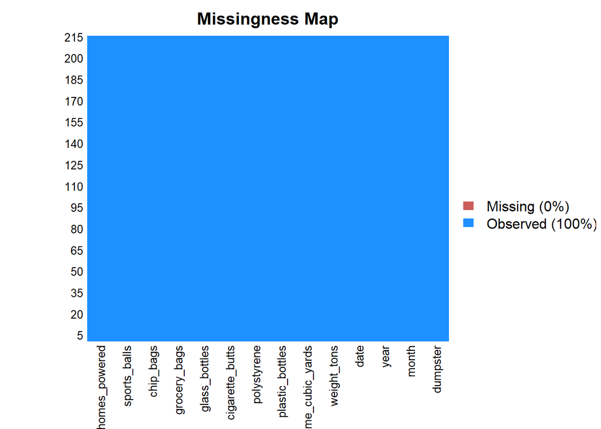

```r
 trash_wheel_data
```

```
## # A tibble: 215 x 14
##    dumpster month  year date                weight_tons volume_cubic_ya~
##       <dbl> <chr> <dbl> <dttm>                    <dbl>            <dbl>
##  1        1 May    2014 2014-05-16 00:00:00        4.31               18
##  2        2 May    2014 2014-05-16 00:00:00        2.74               13
##  3        3 May    2014 2014-05-16 00:00:00        3.45               15
##  4        4 May    2014 2014-05-17 00:00:00        3.1                15
##  5        5 May    2014 2014-05-17 00:00:00        4.06               18
##  6        6 May    2014 2014-05-20 00:00:00        2.71               13
##  7        7 May    2014 2014-05-21 00:00:00        1.91                8
##  8        8 May    2014 2014-05-28 00:00:00        3.7                16
##  9        9 June   2014 2014-06-05 00:00:00        2.52               14
## 10       10 June   2014 2014-06-11 00:00:00        3.76               18
## # ... with 205 more rows, and 8 more variables: plastic_bottles <dbl>,
## #   polystyrene <dbl>, cigarette_butts <dbl>, glass_bottles <dbl>,
## #   grocery_bags <dbl>, chip_bags <dbl>, sports_balls <int>,
## #   homes_powered <dbl>
```

instruction:“Read and clean precipitation data for 2016 and 2017. For each, omit rows without precipitation data and add a variable year. Next, combine datasets and convert month to a character variable (the variable month.name is built into R and should be useful).”

```r
precip_2017 <- readxl::read_excel(path =
    "./problem2/HealthyHarborWaterWheelTotals2017-9-26.xlsx",
  sheet =  "2017 Precipitation",
  skip = 2, col_names = c("month", "tot_precip")) %>%
  na.omit() %>%
  as.tibble() %>%
  mutate(year = 2017)
precip_2016 <- readxl::read_excel(path =
    "./problem2/HealthyHarborWaterWheelTotals2017-9-26.xlsx",
  sheet =  "2016 Precipitation",
  skip = 2,
  col_names = c("month", "tot_precip")) %>%
  na.omit() %>%
  as.tibble() %>%
  mutate(year = 2016)
precip_2017_2016 <- dplyr::bind_rows(precip_2016,precip_2017) %>%
  mutate(month = month.name[month])
```

```r
sapply(X = trash_wheel_data, function(x) if( is.numeric(x) ) { e1071::kurtosis(x) } )
```

```
## $dumpster
## [1] -1.216757
##
## $month
## NULL
##
## $year
## [1] -1.235836
##
## $date
## NULL
##
## $weight_tons
## [1] -0.2897415
##
## $volume_cubic_yards
## [1] 3.413174
##
## $plastic_bottles
## [1] -0.2486567
##
## $polystyrene
## [1] -0.3853014
##
## $cigarette_butts
## [1] 10.89873
##
## $glass_bottles
## [1] 1.003026
##
## $grocery_bags
## [1] -1.021889
##
## $chip_bags
## [1] -0.740205
##
## $sports_balls
## [1] 0.4257788
##
## $homes_powered
## [1] -1.347481
```

```r
sapply(X = trash_wheel_data, function(x) if( is.numeric(x) ) { e1071::kurtosis(x) } )
```

```
## $dumpster
## [1] -1.216757
##
## $month
## NULL
##
## $year
## [1] -1.235836
##
## $date
## NULL
##
## $weight_tons
## [1] -0.2897415
##
## $volume_cubic_yards
## [1] 3.413174
##
## $plastic_bottles
## [1] -0.2486567
##
## $polystyrene
## [1] -0.3853014
##
## $cigarette_butts
## [1] 10.89873
##
## $glass_bottles
## [1] 1.003026
##
## $grocery_bags
## [1] -1.021889
##
## $chip_bags
## [1] -0.740205
##
## $sports_balls
## [1] 0.4257788
##
## $homes_powered
## [1] -1.347481
```

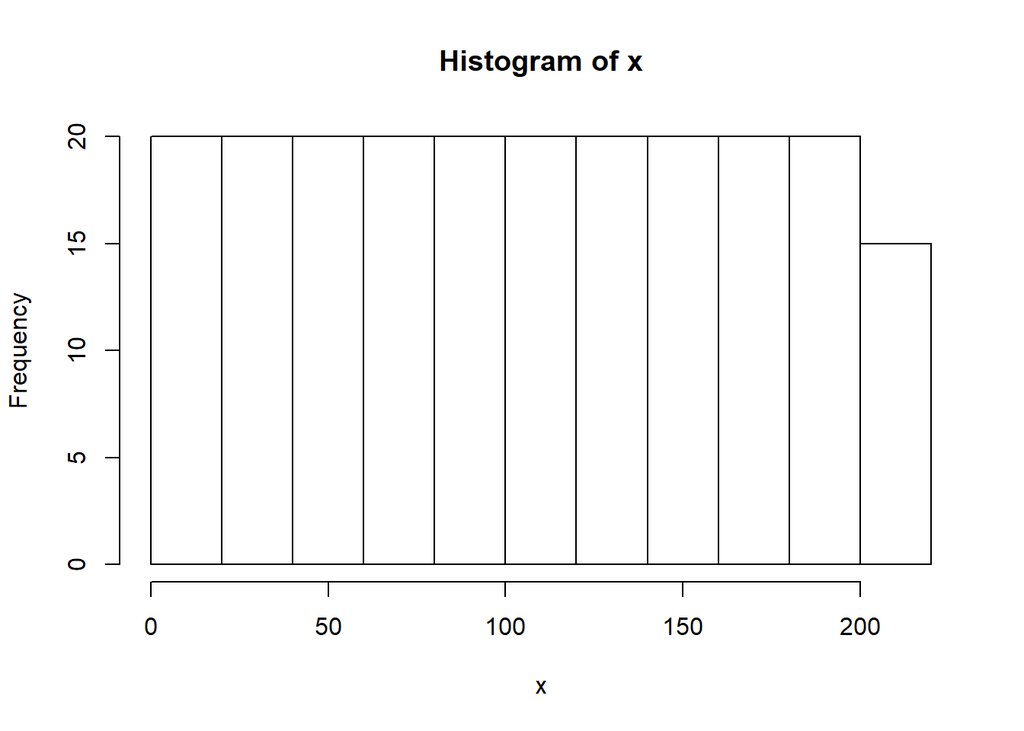

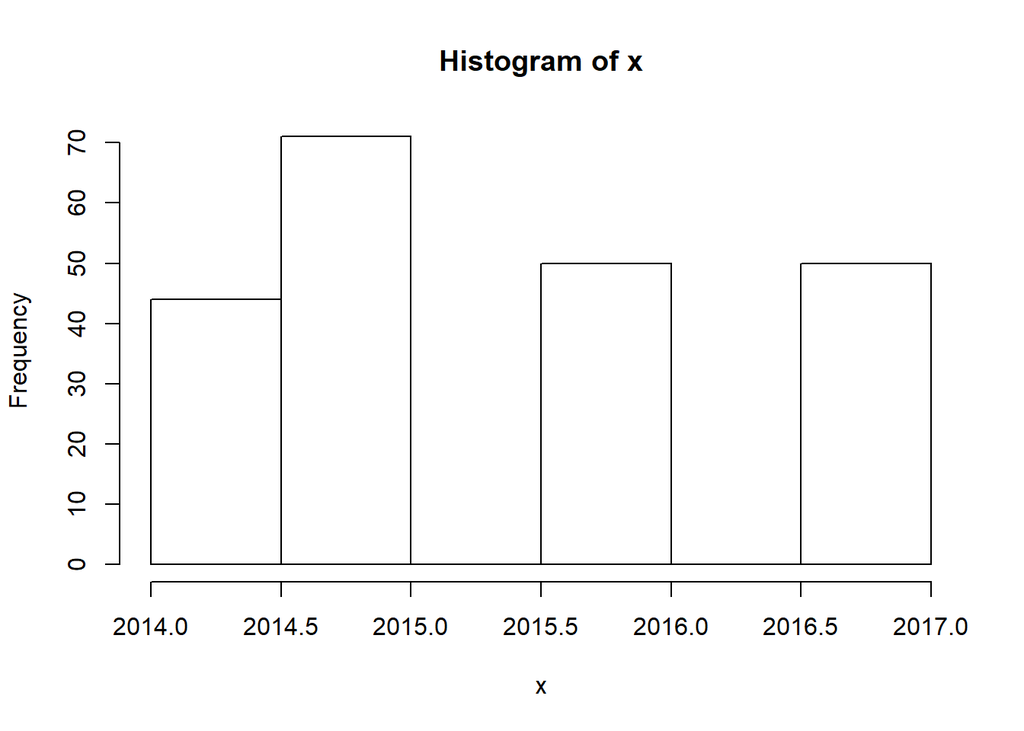

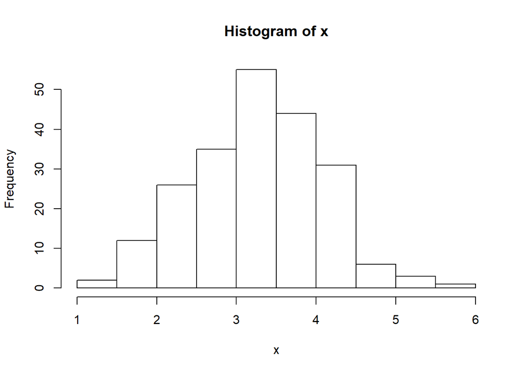

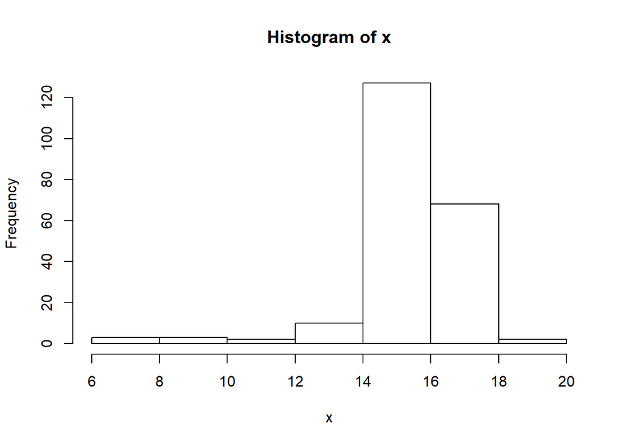

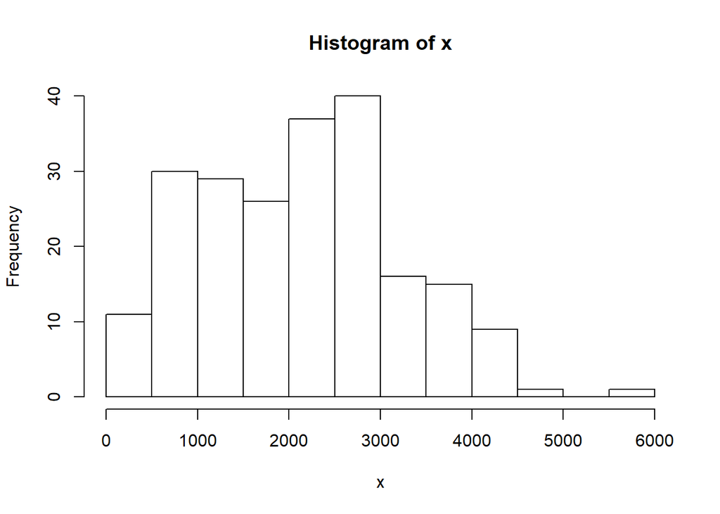

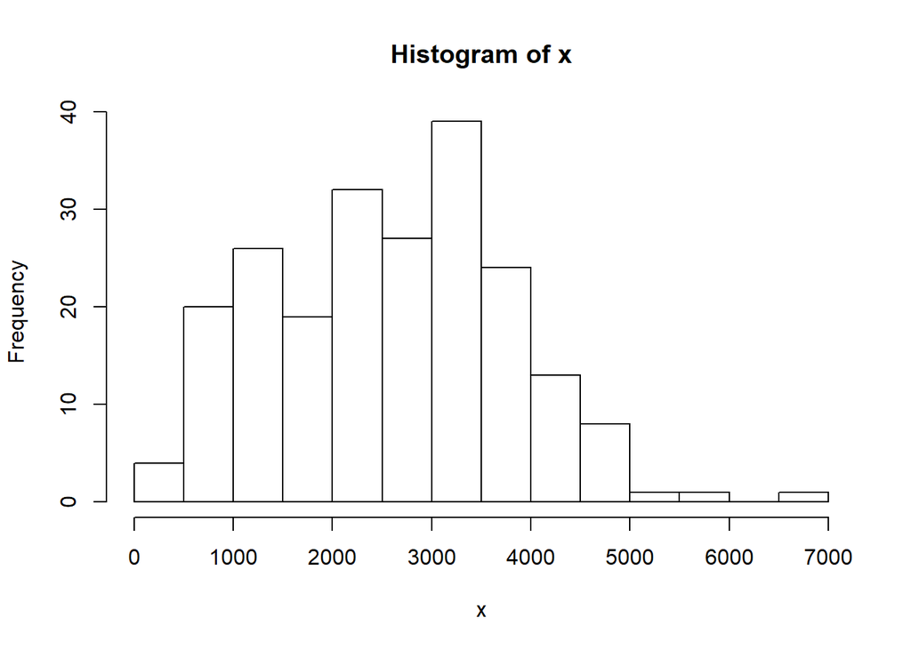

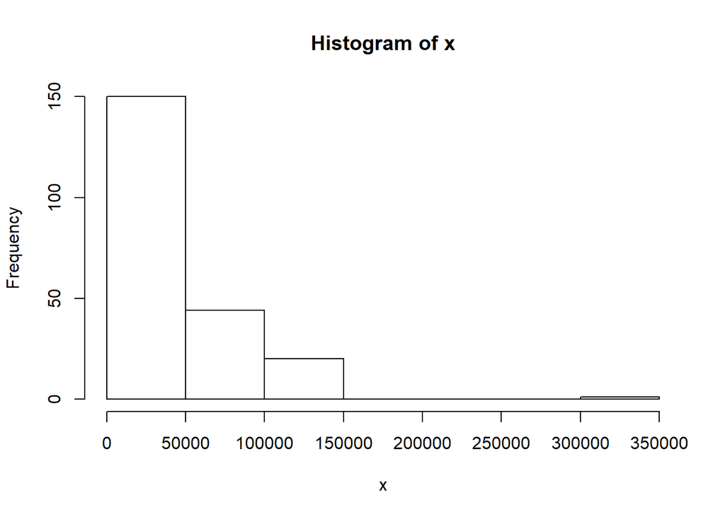

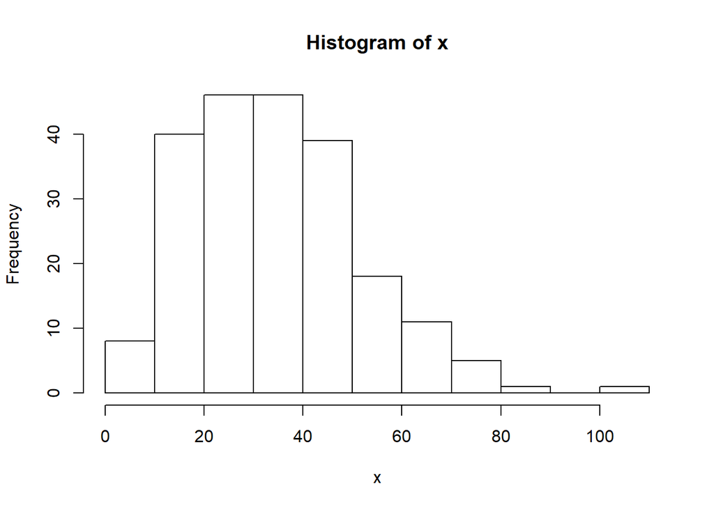

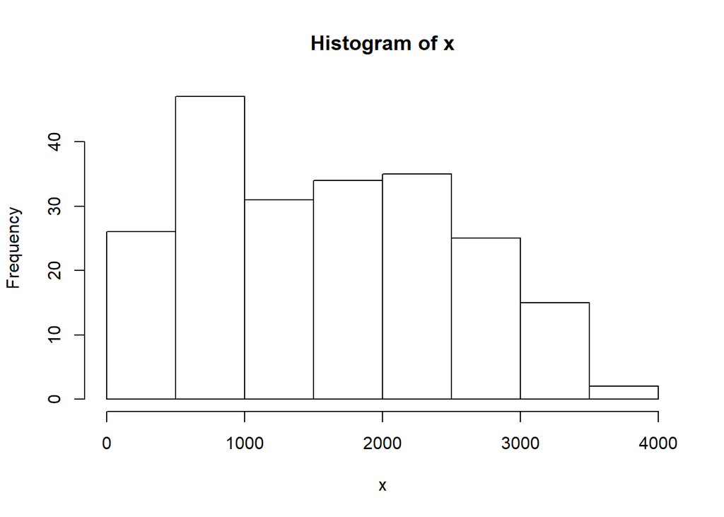

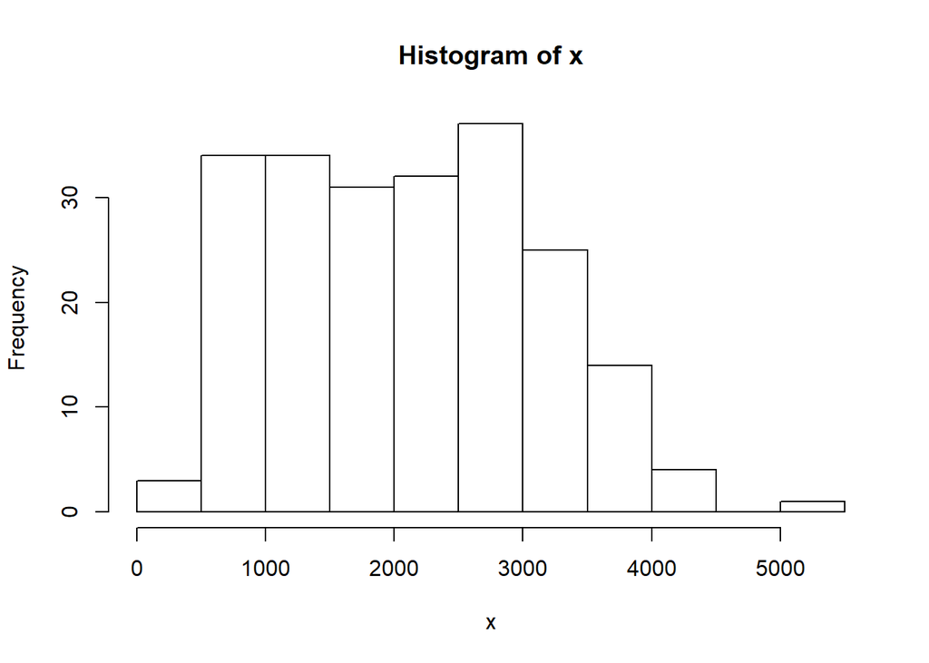

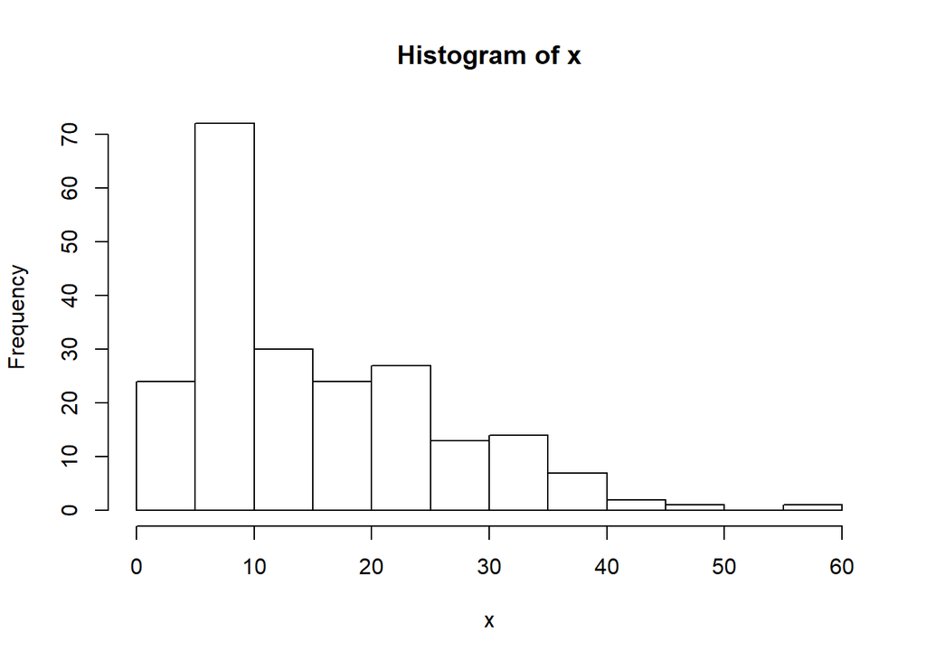

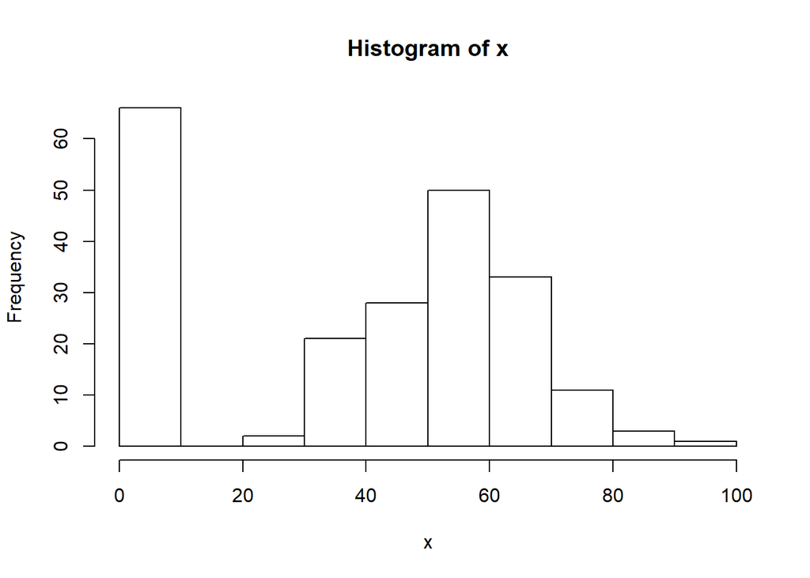

[output not shown]

[output cut: 232 more lines]

[output not shown]

```r
sapply(X = trash_wheel_data, function(x) if( is.numeric(x) ) {  hist(x) } )
```

```r
sapply(colnames(trash_wheel_data),function(x) if(is.numeric(trash_wheel_data[,x])) {  hist(trash_wheel_data[,x],main=x) })
```

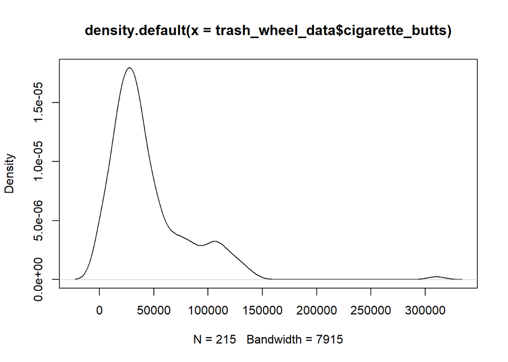

```r
#sapply(colnames(trash_wheel_data),function(x) { is.numeric(trash_wheel_data[,x])})
density(trash_wheel_data$cigarette_butts) %>% plot()
```

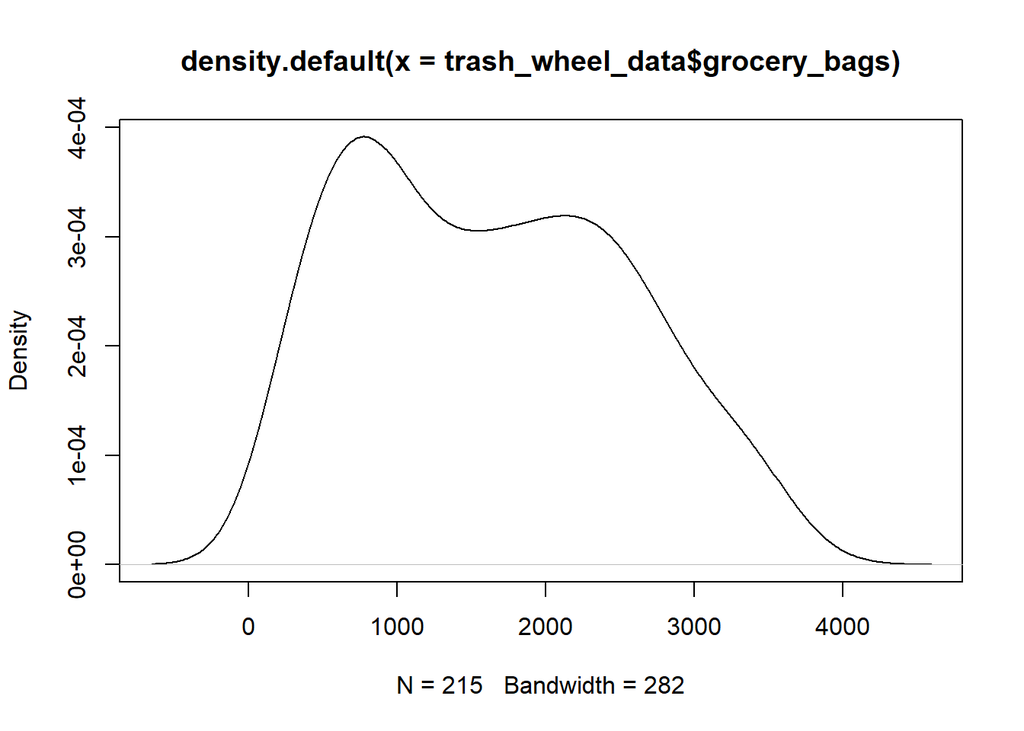

```r
density(trash_wheel_data$grocery_bags) %>% plot()
```

# Problem 3(finish the paragraph in 2)

“This problem uses the BRFSS data. DO NOT include this dataset in your local data directory; instead, load the data from the p8105.datasets package.

For this question:

format the data to use appropriate variable names; focus on the “Overall Health” topic exclude variables for class, topic, question, sample size, and everything from lower confidence limit to GeoLocation structure data so that responses (excellent to poor) are variables taking the value of Data_value create a new variable showing the proportion of responses that were “Excellent” or “Very Good”"

```r
brfss <- p8105.datasets::brfss_smart2010 %>% janitor::clean_names() %>%
  filter(topic == "Overall Health") %>%
  select(-class,-topic,-question,-sample_size,-(confidence_limit_low:geo_location)) %>%
    spread(key = response,value=data_value) %>%
   janitor::clean_names() %>%
  mutate(ex_very_good = excellent + very_good)
brfss
```

```
## # A tibble: 2,125 x 9
##     year locationabbr locationdesc excellent  fair  good  poor very_good
##    <int> <chr>        <chr>            <dbl> <dbl> <dbl> <dbl>     <dbl>
##  1  2002 AK           AK - Anchor~      27.9   8.6  23.8   5.9      33.7
##  2  2002 AL           AL - Jeffer~      18.5  12.1  32.7   5.9      30.9
##  3  2002 AR           AR - Pulask~      24.1  12.5  29.9   4.2      29.3
##  4  2002 AZ           AZ - Marico~      21.6  10.3  26.9   4.6      36.6
##  5  2002 AZ           AZ - Pima C~      26.6   7.5  31.9   3.9      30.1
##  6  2002 CA           CA - Los An~      22.7  14.3  28.7   4.5      29.8
##  7  2002 CO           CO - Adams ~      21.2  14.4  29     4.2      31.2
##  8  2002 CO           CO - Arapah~      25.5   8    29.3   2.1      35.2
##  9  2002 CO           CO - Denver~      22.2  11.1  36.6   3        27.1
## 10  2002 CO           CO - Jeffer~      23.4  11.4  26.3   2.4      36.6
## # ... with 2,115 more rows, and 1 more variable: ex_very_good <dbl>
```

Instruction: “Using this dataset, do or answer the following:

How many unique locations are included in the dataset? Is every state represented? What state is observed the most? In 2002, what is the median of the “Excellent” response value? Make a histogram of “Excellent” response values in the year 2002. Make a scatterplot showing the proportion of “Excellent” response values in New York County and Queens County (both in NY State) in each year from 2002 to 2010." ###### Number of unique locations in dataset

```r
unique_locations <- brfss %>%
  select( locationdesc ) %>%
  distinct() %>%
  nrow()
unique_locations
```

```
## [1] 404
```

```r
n_states <- brfss %>%
  select( locationabbr ) %>%
  distinct() %>%
  nrow()
n_states
```

```
## [1] 51
```

```r
all_states <- brfss %>%
  select( locationabbr ) %>%
  distinct() %>%
  table() %>%
  names()
all_states
```

```
##  [1] "AK" "AL" "AR" "AZ" "CA" "CO" "CT" "DC" "DE" "FL" "GA" "HI" "IA" "ID"
## [15] "IL" "IN" "KS" "KY" "LA" "MA" "MD" "ME" "MI" "MN" "MO" "MS" "MT" "NC"
## [29] "ND" "NE" "NH" "NJ" "NM" "NV" "NY" "OH" "OK" "OR" "PA" "RI" "SC" "SD"
## [43] "TN" "TX" "UT" "VA" "VT" "WA" "WI" "WV" "WY"
```

```r
most_observed_states <- brfss %>%
  select( locationabbr ) %>%
  table() %>%
  sort(decreasing = T) %>%
  head()
most_observed_states
```

```
## .
##  NJ  FL  NC  WA  MD  MA
## 146 122 115  97  90  79
```

```r
most_observed_state <- most_observed_states %>%
  names() %>% .[1]
most_observed_state
```

```
## [1] "NJ"
```

```r
median_ex_2002  <- brfss %>%
  filter(year == 2002) %>%
  pull(excellent) %>%
  na.omit() %>%
  median()
```

The number of unique locations is 404, achieved by selecting distinct locations and counting the rows. We find that all 50 states and the district of columbia are observed by the distinct count of 51 and observing that all the states observed in “all_states” contain only state or DC abbreviations. The most observed state is NJ. The median of excellent responses in 2002 was 23.6.

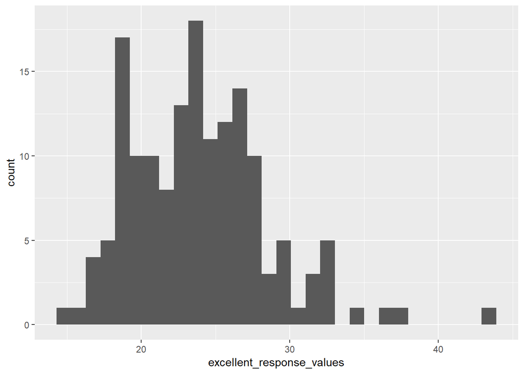

```r
excellent_response_values <- brfss %>%
  filter(year == 2002) %>%
  pull(excellent) %>%
  na.omit()
  ggplot(data=NULL,
         aes(x=excellent_response_values)) +
    geom_histogram()
```